# Project NeverGiveUp

Jinhan & Ming

12/8/2017

# Never Give Up

## Never Give Up

We are Never Give Up team, and we truly are.

- Team memeber:Jinhan Cheng, Ming Li

## TOPIC: Trade Around the World

- Trade
- Index

## Very Raw Data

- Lots of columns, and we only deal with total import and export

```r
colnames(dat3)
```

```
 [1] "Year"                            "SITC"
 [3] "sitc_sdesc"                      "Country"
 [5] "ExportsFASValueBasisJan"         "GenImportsCustomsValBasisJan"
 [7] "GenImportsCIFValBasisJan"        "ExportsFASValueBasisFeb"
 [9] "GenImportsCustomsValBasisFeb"    "GenImportsCIFValBasisFeb"
[11] "ExportsFASValueBasisMar"         "GenImportsCustomsValBasisMar"
[13] "GenImportsCIFValBasisMar"        "ExportsFASValueBasisApr"
[15] "GenImportsCustomsValBasisApr"    "GenImportsCIFValBasisApr"
[17] "ExportsFASValueBasisMay"         "GenImportsCustomsValBasisMay"
[19] "GenImportsCIFValBasisMay"        "ExportsFASValueBasisJun"
[21] "GenImportsCustomsValBasisJun"    "GenImportsCIFValBasisJun"
[23] "ExportsFASValueBasisJul"         "GenImportsCustomsValBasisJul"
[25] "GenImportsCIFValBasisJul"        "ExportsFASValueBasisAug"
[27] "GenImportsCustomsValBasisAug"    "GenImportsCIFValBasisAug"
[29] "ExportsFASValueBasisSep"         "GenImportsCustomsValBasisSep"
[31] "GenImportsCIFValBasisSep"        "ExportsFASValueBasisOct"
[33] "GenImportsCustomsValBasisOct"    "GenImportsCIFValBasisOct"
[35] "ExportsFASValueBasisNov"         "GenImportsCustomsValBasisNov"
[37] "GenImportsCIFValBasisNov"        "ExportsFASValueBasisDec"
[39] "GenImportsCustomsValBasisDec"    "GenImportsCIFValBasisDec"
[41] "ExportsFASValueBasisYtdDec"      "GenImportsCustomsValBasisYtdDec"
[43] "GenImportsCIFValBasisYtdDec"     "CTY_CODE"
```

## Annual Reports from WTO

```r
rp.files <- list.files(pattern = "world_trade_report")
rp.files
```

```
 [1] "world_trade_report07_e.pdf" "world_trade_report08_e.pdf"
 [3] "world_trade_report09_e.pdf" "world_trade_report10_e.pdf"
 [5] "world_trade_report11_e.pdf" "world_trade_report12_e.pdf"
 [7] "world_trade_report13_e.pdf" "world_trade_report14_e.pdf"
 [9] "world_trade_report15_e.pdf" "world_trade_report16_e.pdf"
[11] "world_trade_report17_e.pdf"
```

## Simple Text Miming

```r
read <- readPDF(control = list(text = "-layout"))
text <- Corpus(URISource(rp.files), readerControl = list(reader = read))
text.p <- TermDocumentMatrix(text, control = list(removePunctuation = TRUE,
    stopwords = TRUE, tolower = TRUE, stemming = TRUE, removeNumbers = TRUE,
    bounds = list(local = c(3, Inf))))
ft <- findFreqTerms(text.p, highfreq = Inf)
goods <- unique(dat3$sitc_sdesc)
goods <- tolower(goods)
goods.p <- sprintf(" %s ", paste(goods, collapse = " "))
goods.p <- gsub("\\d", " ", goods.p)
goods.p <- gsub(pattern = "[[:punct:]]", replacement = "", goods.p)
goods.p <- unique(unlist(strsplit(goods.p, split = " ")))
goods.p <- goods.p[which(nchar(goods.p) >= 3)]
goods.p <- sort(goods.p[which(goods.p %in% ft)])
text.ft <- as.matrix(text.p[goods.p, ])
text.ft <- cbind(rownames(text.ft), as.data.table(text.ft))
colnames(text.ft)[1] <- "Term"
text.ft$Frequence <- rowSums(text.ft[, 2:12, by = "Term"])
text.c <- text.ft[, c(1, 13)]
text.clean <- c("paper", "oil", "food", "fuel", "water", "fish",
    "plant", "gas", "steel", "household", "metal", "wood", "iron",
    "coal", "petroleum", "footwear", "ore", "apparel", "gold",
    "meat", "fruit", "aircraft", "leather", "sugar", "cotton",
    "railway", "wheat", "rice", "motor", "gluten", "cocoa", "copper",
    "film", "corn", "rubber", "tobacco", "nickel", "tea", "headgear",
    "milk", "cork", "silver", "cereal", "honey", "plywood", "zinc",
    "platinum", "sand", "flour")
text.cleaned <- text.c[text.c$Term %in% text.clean, ]
text.cleaned <- setorderv(text.cleaned, "Frequence", -1)
rm(text.ft)
```

## Frequence

```r
datatable(text.cleaned)
```

|  | Term | Frequence |
| --- | --- | --- |
| 1 | paper | 1314 |
| 2 | oil | 651 |
| 3 | food | 637 |
| 4 | fuel | 501 |
| 5 | water | 277 |
| 6 | fish | 229 |
| 7 | plant | 210 |
| 8 | gas | 181 |
| 9 | steel | 173 |
| 10 | household | 167 |

[output cut: 39 more lines]

## A Coarse Accumulated WordCloud for 2006-2017

- Not precise enough because it contains some words that are useless
- Let’s take a look at shiny to see more precise trend in these years

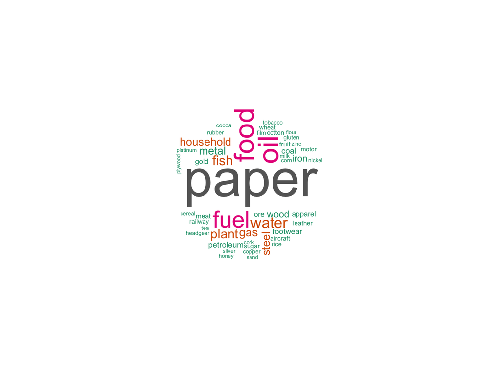

```r
wordcloud(text.cleaned$Term, text.cleaned$Frequence, random.order = FALSE,
    scale = c(5, 0.5), colors = brewer.pal(8, "Dark2"))
```

# Key Words

## Key Words

- Manually drag them from the wordcloud
- Use also some Brain Storm
- Two versions of key words, the full names and the short names(which are easy to grepl())

```r
keywords
```

```
 [1] "SILK TEXTILE FIBERS"
 [2] "COTTON TEXTILE FIBERS"
 [3] "WHEAT AND MESLIN, UNMILLED"
 [4] "RICE"
 [5] "BARLEY, UNMILLED"
 [6] "MAIZE (NOT INCLUDING SWEET CORN) UNMILLED"
 [7] "CEREALS, EXCEPT WHEAT, RICE, BARLEY, MAIZE"
 [8] "COFFEE AND COFFEE SUBSTITUTES"
 [9] "COCOA"
[10] "TEA AND MATE"
[11] "NONALCOHOLIC BEVERAGES"
[12] "ALCOHOLIC BEVERAGES"
[13] "MILK, CREAM, MILK PRODUCTS EXCEPT BUTTER OR CHEES"
[14] "FRUIT/VEGETABLE JUICES, UNFERMENTED"
```

```r
s.keywords
```

```
 [1] "Silk"          "Cotton"        "Wheat"         "Rice"
 [5] "Barley"        "Maize"         "Other.Cereals" "Coffee"
 [9] "Cocoa"         "Tea"           "Soft.Drinks"   "Alcohol"
[13] "Milk"          "Juices"
```

# Melt Data and Clean them

## Adding Population Growth

- We already have these columns, and we add other variables from now on (including country code)
- The name of a country may be written in different way, but all point to the same country code!
- But also, we drop some data because some country don’t have their corresponding code.

```r
colnames(total.keydat)
```

```
 [1] "Country"       "Year"          "Type"          "Silk"
 [5] "Cotton"        "Wheat"         "Rice"          "Barley"
 [9] "Maize"         "Other.Cereals" "Coffee"        "Cocoa"
[13] "Tea"           "Soft.Drinks"   "Alcohol"       "Milk"
[17] "Juices"
```

## Adding other Variables

- Undernourishment (for example)
- Overweight
- Death caused by nourishment condition
- Income_male, Income_female, GDP per person

```r
undernourishment <- fread(input = "Undernourishment.csv")
overweight <- fread(input = "Overweight.csv")
death <- fread(input = "Cause_of_Death_by.csv")
income_male <- fread(input = "Income_Male.csv")
income_female <- fread(input = "Income_Female.csv")
gdp_p <- fread(input = "GDP_Per_Person.csv")
```

```r
# choose
# data
# from
# 1996-2016
undernourishment <- undernourishment[, c("Country Code", "1996":"2016")]
undernourishment <- melt(data = undernourishment, id.vars = "Country Code",
    variable.name = "Year", value.name = "Undernourishment",
    value.factor = FALSE)
undernourishment[, `:=`(Year, as.numeric(as.character(Year)))]
undernourishment[, `:=`(Undernourishment, as.numeric(Undernourishment))]
undernourishment[`Country Code` == "USA", `:=`(U.N.U.S, Undernourishment),
    by = Year]
undernourishment[, `:=`(U.N.U.S, mean(U.N.U.S, na.rm = TRUE)),
    by = Year]
```

## Merging

```r
total.keydat <- merge(total.keydat, undernourishment[`Country Code` %in%
    unique(total.keydat$`Country Code`), c("Country Code", "Year",
    "Undernourishment", "U.N.U.S")], by = c("Country Code", "Year"),
    all = FALSE)
total.keydat <- merge(total.keydat, overweight[`Country Code` %in%
    unique(total.keydat$`Country Code`), c("Country Code", "Year",
    "Overweight", "O.W.U.S")], by = c("Country Code", "Year"),
    all = FALSE)
total.keydat <- merge(total.keydat, death[`Country Code` %in%
    unique(total.keydat$`Country Code`), c("Country Code", "Year",
    "Death", "D.U.S")], by = c("Country Code", "Year"), all = FALSE)
total.keydat <- merge(total.keydat, income_male[`Country Code` %in%
    unique(total.keydat$`Country Code`), c("Country Code", "Year",
    "Income_Male", "I.M.U.S")], by = c("Country Code", "Year"),
    all = FALSE)
total.keydat <- merge(total.keydat, income_female[`Country Code` %in%
    unique(total.keydat$`Country Code`), c("Country Code", "Year",
    "Income_Female", "I.F.U.S")], by = c("Country Code", "Year"),
    all = FALSE)
total.keydat <- merge(total.keydat, gdp_p[`Country Code` %in%
    unique(total.keydat$`Country Code`), c("Country Code", "Year",
    "GDP.per.person", "Gdp.P.U.S")], by = c("Country Code", "Year"),
    all = FALSE)
setorderv(total.keydat, c("Country", "Year"))

setcolorder(x = total.keydat, neworder = c("Country Code", "Year",
    "Country", "Region", "IncomeGroup", "Type", "Silk", "Cotton",
    "Wheat", "Rice", "Barley", "Maize", "Other.Cereals", "Coffee",
    "Cocoa", "Tea", "Soft.Drinks", "Alcohol", "Milk", "Juices",
    "Population.Growth", "Undernourishment", "Overweight", "Death",
    "Income_Male", "Income_Female", "GDP.per.person", "P.G.U.S",
    "U.N.U.S", "O.W.U.S", "D.U.S", "I.M.U.S", "I.F.U.S", "Gdp.P.U.S"))
```

# Modeling

## Using Ratio rather than Real Amount

- Suppose amount of Import and Export equals to what have been consumed in reality.
- We have 3 product groups, cloth, cereal and drinks, because the amount of the trade is enormous, we use ratio instead of real amount here. We want to see what the changes of ratios between products could affect the indexs.

## Model Overweight (Export from US)

- One is more likely to be overweight, if he or she drinks a lot Cocoa and Tea?(maybe drink with lots of sugar)
- Now let’s take a look at shiny

```r
overweight.formula <- " Overweight ~ IncomeGroup + Region + Wheat + Rice + Barley + Maize + Other.Cereals + Coffee + Cocoa + Tea + Soft.Drinks + Alcohol + Milk + Juices"
overweight.model <- fit.model(dat = ratio.keydat[Type == "Export",
    ], the.initial.formula = overweight.formula, model.type = "linear")
datatable(overweight.model)
```

|  | Variable | Estimate | Std. Error | t value | p.value | Coef.Lower.95 | Coef.Upper.95 |
| --- | --- | --- | --- | --- | --- | --- | --- |
| 1 | (Intercept) | 5.218 | 2.309 | 2.26 | 0.025 | 0.693 | 9.743 |
| 2 | IncomeGroupLow income | -1.586 | 1.311 | -1.209 | 0.228 | -4.156 | 0.984 |
| 3 | IncomeGroupLower middle income | 0.212 | 1.053 | 0.201 | 0.841 | -1.852 | 2.275 |
| 4 | IncomeGroupUpper middle income | 0.348 | 1.056 | 0.33 | 0.742 | -1.722 | 2.418 |
| 5 | RegionEurope &amp; Central Asia | 8.105 | 1.225 | 6.615 | 0 | 5.704 | 10.507 |
| 6 | RegionLatin America &amp; Caribbean | 1.731 | 1.102 | 1.571 | 0.118 | -0.429 | 3.892 |
| 7 | RegionMiddle East &amp; North Africa | 5.362 | 1.202 | 4.46 | 0 | 3.006 | 7.719 |
| 8 | RegionSouth Asia | -3.293 | 1.403 | -2.347 | 0.02 | -6.042 | -0.544 |
| 9 | RegionSub-Saharan Africa | 0.515 | 1.154 | 0.446 | 0.656 | -1.747 | 2.776 |
| 10 | Wheat | -0.4 | 1.366 | -0.292 | 0.77 | -3.077 | 2.278 |

[output cut: 9 more lines]

## Model Coffee (Export from US)

- If you are a man, you may buy less coffee with increasing ratio of salaried male.
- See Shiny

```r
Coffee.formula <- " Coffee ~ IncomeGroup + Region + GDP.per.person + Income_Female + Income_Male"
Coffee.model <- fit.model(dat = ratio.keydat[Type == "Export",
    ], the.initial.formula = Coffee.formula, model.type = "linear")
datatable(Coffee.model)
```

|  | Variable | Estimate | Std. Error | t value | p.value | Coef.Lower.95 | Coef.Upper.95 |
| --- | --- | --- | --- | --- | --- | --- | --- |
| 1 | (Intercept) | -0.071 | 0.041 | -1.706 | 0.088 | -0.152 | 0.011 |
| 2 | IncomeGroupLow income | 0.152 | 0.051 | 2.985 | 0.003 | 0.052 | 0.252 |
| 3 | IncomeGroupLower middle income | 0.077 | 0.025 | 3.018 | 0.003 | 0.027 | 0.127 |
| 4 | IncomeGroupUpper middle income | 0.043 | 0.016 | 2.649 | 0.008 | 0.011 | 0.074 |
| 5 | RegionEurope &amp; Central Asia | -0.014 | 0.016 | -0.895 | 0.371 | -0.045 | 0.017 |
| 6 | RegionLatin America &amp; Caribbean | 0.014 | 0.019 | 0.747 | 0.455 | -0.023 | 0.052 |
| 7 | RegionMiddle East &amp; North Africa | 0.028 | 0.024 | 1.167 | 0.244 | -0.019 | 0.076 |
| 8 | RegionNorth America | -0.044 | 0.036 | -1.209 | 0.227 | -0.114 | 0.027 |
| 9 | RegionSouth Asia | 0.02 | 0.044 | 0.453 | 0.651 | -0.067 | 0.107 |
| 10 | RegionSub-Saharan Africa | 0.023 | 0.031 | 0.749 | 0.454 | -0.038 | 0.085 |

[output cut: 3 more lines]

## Model Tea (Export from US)

- If you are a man, you may buy more tea with increaing wage
- See Shiny

```r
Tea.formula <- " Tea ~ IncomeGroup + Region + GDP.per.person + Income_Female + Income_Male"
Tea.model <- fit.model(dat = ratio.keydat[Type == "Export", ],
    the.initial.formula = Tea.formula, model.type = "linear")
datatable(Tea.model)
```

|  | Variable | Estimate | Std. Error | t value | p.value | Coef.Lower.95 | Coef.Upper.95 |
| --- | --- | --- | --- | --- | --- | --- | --- |
| 1 | (Intercept) | -0.083 | 0.029 | -2.831 | 0.005 | -0.141 | -0.026 |
| 2 | IncomeGroupLow income | 0.021 | 0.036 | 0.588 | 0.556 | -0.049 | 0.092 |
| 3 | IncomeGroupLower middle income | 0.054 | 0.018 | 2.975 | 0.003 | 0.018 | 0.089 |
| 4 | IncomeGroupUpper middle income | 0.02 | 0.011 | 1.799 | 0.072 | -0.002 | 0.043 |
| 5 | RegionEurope &amp; Central Asia | 0.03 | 0.011 | 2.693 | 0.007 | 0.008 | 0.052 |
| 6 | RegionLatin America &amp; Caribbean | 0.038 | 0.014 | 2.797 | 0.005 | 0.011 | 0.065 |
| 7 | RegionMiddle East &amp; North Africa | 0.081 | 0.017 | 4.713 | 0 | 0.048 | 0.115 |
| 8 | RegionNorth America | 0.011 | 0.026 | 0.43 | 0.667 | -0.039 | 0.061 |
| 9 | RegionSouth Asia | 0.016 | 0.031 | 0.493 | 0.622 | -0.046 | 0.077 |
| 10 | RegionSub-Saharan Africa | 0.076 | 0.022 | 3.436 | 0.001 | 0.033 | 0.12 |

[output cut: 3 more lines]

## Model Cocoa (Export from US)

```r
Cocoa.formula <- " Cocoa ~ IncomeGroup + Region + GDP.per.person + Income_Female + Income_Male"
Cocoa.model <- fit.model(dat = ratio.keydat[Type == "Export",
    ], the.initial.formula = Cocoa.formula, model.type = "linear")
datatable(Cocoa.model)
```

|  | Variable | Estimate | Std. Error | t value | p.value | Coef.Lower.95 | Coef.Upper.95 |
| --- | --- | --- | --- | --- | --- | --- | --- |
| 1 | (Intercept) | -0.002 | 0.012 | -0.16 | 0.873 | -0.025 | 0.021 |
| 2 | IncomeGroupLow income | 0.017 | 0.015 | 1.195 | 0.233 | -0.011 | 0.046 |
| 3 | IncomeGroupLower middle income | -0.002 | 0.007 | -0.241 | 0.81 | -0.016 | 0.013 |
| 4 | IncomeGroupUpper middle income | 0.005 | 0.005 | 1.154 | 0.249 | -0.004 | 0.014 |
| 5 | RegionEurope &amp; Central Asia | 0.006 | 0.004 | 1.336 | 0.182 | -0.003 | 0.015 |
| 6 | RegionLatin America &amp; Caribbean | 0.001 | 0.006 | 0.143 | 0.886 | -0.01 | 0.012 |
| 7 | RegionMiddle East &amp; North Africa | 0.005 | 0.007 | 0.684 | 0.494 | -0.009 | 0.018 |
| 8 | RegionNorth America | 0.004 | 0.01 | 0.388 | 0.698 | -0.016 | 0.024 |
| 9 | RegionSouth Asia | 0 | 0.013 | -0.024 | 0.981 | -0.025 | 0.025 |
| 10 | RegionSub-Saharan Africa | 0.017 | 0.009 | 1.895 | 0.058 | -0.001 | 0.035 |

[output cut: 3 more lines]

## Model Soft Drink (Export from US)

```r
Soft.Drinks.formula <- " Soft.Drinks ~ IncomeGroup + Region + GDP.per.person + Income_Female + Income_Male"
Soft.Drinks.model <- fit.model(dat = ratio.keydat[Type == "Export",
    ], the.initial.formula = Soft.Drinks.formula, model.type = "linear")
datatable(Soft.Drinks.model)
```

|  | Variable | Estimate | Std. Error | t value | p.value | Coef.Lower.95 | Coef.Upper.95 |
| --- | --- | --- | --- | --- | --- | --- | --- |
| 1 | (Intercept) | -0.104 | 0.058 | -1.807 | 0.071 | -0.218 | 0.009 |
| 2 | IncomeGroupLow income | 0.192 | 0.071 | 2.714 | 0.007 | 0.053 | 0.331 |
| 3 | IncomeGroupLower middle income | 0.155 | 0.035 | 4.385 | 0 | 0.086 | 0.225 |
| 4 | IncomeGroupUpper middle income | 0.011 | 0.022 | 0.493 | 0.622 | -0.033 | 0.055 |
| 5 | RegionEurope &amp; Central Asia | -0.115 | 0.022 | -5.276 | 0 | -0.158 | -0.072 |
| 6 | RegionLatin America &amp; Caribbean | -0.107 | 0.027 | -3.978 | 0 | -0.16 | -0.054 |
| 7 | RegionMiddle East &amp; North Africa | -0.153 | 0.034 | -4.5 | 0 | -0.219 | -0.086 |
| 8 | RegionNorth America | -0.238 | 0.05 | -4.738 | 0 | -0.336 | -0.139 |
| 9 | RegionSouth Asia | 0.06 | 0.062 | 0.964 | 0.335 | -0.062 | 0.181 |
| 10 | RegionSub-Saharan Africa | -0.07 | 0.044 | -1.614 | 0.107 | -0.156 | 0.015 |

[output cut: 3 more lines]

## Model Alcohol (Export from US)

```r
Alcohol.formula <- " Alcohol ~ IncomeGroup + Region + GDP.per.person + Income_Female + Income_Male"
Alcohol.model <- fit.model(dat = ratio.keydat[Type == "Export",
    ], the.initial.formula = Alcohol.formula, model.type = "linear")
datatable(Alcohol.model)
```

|  | Variable | Estimate | Std. Error | t value | p.value | Coef.Lower.95 | Coef.Upper.95 |
| --- | --- | --- | --- | --- | --- | --- | --- |
| 1 | (Intercept) | 0.97 | 0.09 | 10.799 | 0 | 0.794 | 1.147 |
| 2 | IncomeGroupLow income | -0.616 | 0.11 | -5.583 | 0 | -0.832 | -0.4 |
| 3 | IncomeGroupLower middle income | -0.38 | 0.055 | -6.892 | 0 | -0.488 | -0.272 |
| 4 | IncomeGroupUpper middle income | -0.206 | 0.035 | -5.936 | 0 | -0.274 | -0.138 |
| 5 | RegionEurope &amp; Central Asia | 0.025 | 0.034 | 0.746 | 0.456 | -0.041 | 0.092 |
| 6 | RegionLatin America &amp; Caribbean | 0.129 | 0.042 | 3.088 | 0.002 | 0.047 | 0.212 |
| 7 | RegionMiddle East &amp; North Africa | -0.018 | 0.053 | -0.345 | 0.73 | -0.122 | 0.085 |
| 8 | RegionNorth America | 0.463 | 0.078 | 5.927 | 0 | 0.31 | 0.616 |
| 9 | RegionSouth Asia | 0.082 | 0.096 | 0.855 | 0.393 | -0.106 | 0.271 |
| 10 | RegionSub-Saharan Africa | -0.013 | 0.068 | -0.185 | 0.853 | -0.146 | 0.12 |

[output cut: 3 more lines]

## Model Milk (Export from US)

```r
Milk.formula <- " Milk ~ IncomeGroup + Region + GDP.per.person + Income_Female + Income_Male"
Milk.model <- fit.model(dat = ratio.keydat[Type == "Export",
    ], the.initial.formula = Milk.formula, model.type = "linear")
datatable(Milk.model)
```

|  | Variable | Estimate | Std. Error | t value | p.value | Coef.Lower.95 | Coef.Upper.95 |
| --- | --- | --- | --- | --- | --- | --- | --- |
| 1 | (Intercept) | 0.238 | 0.082 | 2.899 | 0.004 | 0.077 | 0.399 |
| 2 | IncomeGroupLow income | 0.172 | 0.101 | 1.702 | 0.089 | -0.026 | 0.369 |
| 3 | IncomeGroupLower middle income | 0.052 | 0.05 | 1.031 | 0.303 | -0.047 | 0.151 |
| 4 | IncomeGroupUpper middle income | 0.151 | 0.032 | 4.77 | 0 | 0.089 | 0.213 |
| 5 | RegionEurope &amp; Central Asia | 0.071 | 0.031 | 2.3 | 0.022 | 0.011 | 0.132 |
| 6 | RegionLatin America &amp; Caribbean | -0.069 | 0.038 | -1.803 | 0.072 | -0.144 | 0.006 |
| 7 | RegionMiddle East &amp; North Africa | 0.061 | 0.048 | 1.266 | 0.206 | -0.033 | 0.156 |
| 8 | RegionNorth America | -0.136 | 0.071 | -1.907 | 0.057 | -0.276 | 0.004 |
| 9 | RegionSouth Asia | -0.179 | 0.088 | -2.036 | 0.042 | -0.351 | -0.007 |
| 10 | RegionSub-Saharan Africa | -0.098 | 0.062 | -1.576 | 0.115 | -0.219 | 0.024 |

[output cut: 3 more lines]

## Model Juices (Export from US)

```r
Juices.formula <- " Juices ~ IncomeGroup + Region + GDP.per.person + Income_Female + Income_Male"
Juices.model <- fit.model(dat = ratio.keydat[Type == "Export",
    ], the.initial.formula = Juices.formula, model.type = "linear")
datatable(Juices.model)
```

|  | Variable | Estimate | Std. Error | t value | p.value | Coef.Lower.95 | Coef.Upper.95 |
| --- | --- | --- | --- | --- | --- | --- | --- |
| 1 | (Intercept) | 0.052 | 0.043 | 1.21 | 0.227 | -0.032 | 0.136 |
| 2 | IncomeGroupLow income | 0.061 | 0.053 | 1.164 | 0.245 | -0.042 | 0.165 |
| 3 | IncomeGroupLower middle income | 0.044 | 0.026 | 1.67 | 0.095 | -0.008 | 0.096 |
| 4 | IncomeGroupUpper middle income | -0.024 | 0.017 | -1.461 | 0.144 | -0.057 | 0.008 |
| 5 | RegionEurope &amp; Central Asia | -0.003 | 0.016 | -0.205 | 0.838 | -0.035 | 0.028 |
| 6 | RegionLatin America &amp; Caribbean | -0.007 | 0.02 | -0.342 | 0.733 | -0.046 | 0.032 |
| 7 | RegionMiddle East &amp; North Africa | -0.005 | 0.025 | -0.183 | 0.854 | -0.054 | 0.045 |
| 8 | RegionNorth America | -0.061 | 0.037 | -1.621 | 0.105 | -0.134 | 0.013 |
| 9 | RegionSouth Asia | 0.002 | 0.046 | 0.036 | 0.971 | -0.088 | 0.092 |
| 10 | RegionSub-Saharan Africa | 0.064 | 0.032 | 1.97 | 0.049 | 0 | 0.127 |

[output cut: 3 more lines]

## Model Overweight (Import to US)

```r
overweight.us.formula <- " O.W.U.S ~ Wheat + Rice + Barley + Maize + Other.Cereals + Coffee + Cocoa + Tea + Soft.Drinks + Alcohol + Milk + Juices"
overweight.us.model <- fit.model(dat = ratio.keydat[Type == "Import",
    ], the.initial.formula = overweight.us.formula, model.type = "linear")
datatable(overweight.us.model)
```

|  | Variable | Estimate | Std. Error | t value | p.value | Coef.Lower.95 | Coef.Upper.95 |
| --- | --- | --- | --- | --- | --- | --- | --- |
| 1 | (Intercept) | 7.432 | 0.231 | 32.148 | 0 | 6.979 | 7.885 |
| 2 | Wheat | 0.199 | 0.243 | 0.819 | 0.413 | -0.278 | 0.677 |
| 3 | Rice | 0.117 | 0.142 | 0.827 | 0.409 | -0.161 | 0.395 |
| 4 | Barley | 0.078 | 0.409 | 0.191 | 0.848 | -0.724 | 0.88 |
| 5 | Maize | 0.009 | 0.169 | 0.054 | 0.957 | -0.322 | 0.34 |
| 6 | Coffee | -0.248 | 0.25 | -0.991 | 0.322 | -0.739 | 0.242 |
| 7 | Cocoa | -0.058 | 0.298 | -0.194 | 0.847 | -0.642 | 0.526 |
| 8 | Tea | -0.383 | 0.33 | -1.16 | 0.247 | -1.031 | 0.264 |
| 9 | Soft.Drinks | -0.137 | 0.316 | -0.433 | 0.665 | -0.756 | 0.482 |
| 10 | Alcohol | -0.151 | 0.232 | -0.65 | 0.516 | -0.606 | 0.304 |

[output cut: 1 more lines]

## Model Death (Export from US)

```r
death.formula <- "Death ~ Coffee + Cocoa + Tea + Soft.Drinks + Alcohol + Milk + Juices"
death.model <- fit.model(dat = ratio.keydat[Type == "Export",
    ], the.initial.formula = death.formula, model.type = "linear")
datatable(death.model)
```

|  | Variable | Estimate | Std. Error | t value | p.value | Coef.Lower.95 | Coef.Upper.95 |
| --- | --- | --- | --- | --- | --- | --- | --- |
| 1 | (Intercept) | 32.159 | 4.805 | 6.693 | 0 | 22.742 | 41.577 |
| 2 | Coffee | 5.346 | 9.1 | 0.588 | 0.557 | -12.489 | 23.182 |
| 3 | Cocoa | -3.408 | 18.895 | -0.18 | 0.857 | -40.441 | 33.624 |
| 4 | Tea | 3.628 | 10.386 | 0.349 | 0.727 | -16.728 | 23.985 |
| 5 | Soft.Drinks | -12.36 | 6.945 | -1.78 | 0.076 | -25.973 | 1.252 |
| 6 | Alcohol | -9.269 | 5.466 | -1.696 | 0.091 | -19.983 | 1.445 |
| 7 | Milk | -7.804 | 5.645 | -1.382 | 0.167 | -18.869 | 3.261 |

## Model Undernourishment (Export from US)

- less Barley in the structure of one’s diet will prevent undernourishment?
- Let’s see shiny of the trade of barley

```r
undernourishment.formula <- "Undernourishment ~ IncomeGroup + Region + Wheat + Rice +Barley + Maize + Other.Cereals"
undernourishment.model <- fit.model(dat = ratio.keydat[Type ==
    "Export", ], the.initial.formula = undernourishment.formula,
    model.type = "linear")
datatable(undernourishment.model)
```

|  | Variable | Estimate | Std. Error | t value | p.value | Coef.Lower.95 | Coef.Upper.95 |
| --- | --- | --- | --- | --- | --- | --- | --- |
| 1 | (Intercept) | 10.093 | 1.741 | 5.796 | 0 | 6.68 | 13.506 |
| 2 | IncomeGroupLow income | 24.371 | 1.489 | 16.362 | 0 | 21.452 | 27.29 |
| 3 | IncomeGroupLower middle income | 14.167 | 1.365 | 10.378 | 0 | 11.492 | 16.843 |
| 4 | IncomeGroupUpper middle income | 6.521 | 1.33 | 4.904 | 0 | 3.915 | 9.128 |
| 5 | RegionEurope &amp; Central Asia | -6.327 | 1.453 | -4.356 | 0 | -9.175 | -3.48 |
| 6 | RegionLatin America &amp; Caribbean | 0.094 | 1.025 | 0.092 | 0.927 | -1.915 | 2.104 |
| 7 | RegionMiddle East &amp; North Africa | -2.235 | 1.129 | -1.979 | 0.048 | -4.448 | -0.022 |
| 8 | RegionSouth Asia | -1.022 | 1.528 | -0.669 | 0.504 | -4.017 | 1.974 |
| 9 | RegionSub-Saharan Africa | 0.254 | 1.022 | 0.248 | 0.804 | -1.75 | 2.258 |
| 10 | Wheat | -5.555 | 1.392 | -3.99 | 0 | -8.283 | -2.826 |

[output cut: 3 more lines]

## Model Silk (Export from US)

- Male are more likely to buy silk product with increaing ratio of salaried male

```r
Silk.formula <- "Silk ~ IncomeGroup + Region + GDP.per.person + Income_Female + Income_Male"
Silk.model <- fit.model(dat = ratio.keydat[Type == "Export",
    ], the.initial.formula = Silk.formula, model.type = "linear")
datatable(Silk.model)
```

|  | Variable | Estimate | Std. Error | t value | p.value | Coef.Lower.95 | Coef.Upper.95 |
| --- | --- | --- | --- | --- | --- | --- | --- |
| 1 | (Intercept) | 0.033 | 0.084 | 0.394 | 0.694 | -0.131 | 0.197 |
| 2 | IncomeGroupLow income | 0.065 | 0.091 | 0.71 | 0.478 | -0.114 | 0.243 |
| 3 | IncomeGroupLower middle income | -0.009 | 0.053 | -0.173 | 0.863 | -0.112 | 0.094 |
| 4 | IncomeGroupUpper middle income | -0.022 | 0.033 | -0.677 | 0.499 | -0.086 | 0.042 |
| 5 | RegionEurope &amp; Central Asia | -0.068 | 0.045 | -1.53 | 0.127 | -0.156 | 0.019 |
| 6 | RegionLatin America &amp; Caribbean | -0.088 | 0.047 | -1.882 | 0.06 | -0.181 | 0.004 |
| 7 | RegionMiddle East &amp; North Africa | -0.061 | 0.056 | -1.098 | 0.273 | -0.171 | 0.048 |
| 8 | RegionNorth America | -0.109 | 0.063 | -1.729 | 0.084 | -0.232 | 0.014 |
| 9 | RegionSouth Asia | -0.139 | 0.11 | -1.254 | 0.21 | -0.355 | 0.078 |
| 10 | RegionSub-Saharan Africa | -0.139 | 0.067 | -2.062 | 0.04 | -0.271 | -0.007 |

[output cut: 3 more lines]

## Model Silk (Import to US)

```r
Silk.us.formula <- "Silk ~ Gdp.P.U.S + I.M.U.S + I.F.U.S"
Silk.us.model <- fit.model(dat = ratio.keydat[Type == "Import",
    ], the.initial.formula = Silk.us.formula, model.type = "linear")
datatable(Silk.us.model)
```

|  | Variable | Estimate | Std. Error | t value | p.value | Coef.Lower.95 | Coef.Upper.95 |
| --- | --- | --- | --- | --- | --- | --- | --- |
| 1 | (Intercept) | 1.184 | 9.315 | 0.127 | 0.899 | -17.073 | 19.44 |
| 2 | Gdp.P.U.S | 0 | 0 | 0.232 | 0.816 | 0 | 0 |
| 3 | I.M.U.S | 0.023 | 0.055 | 0.427 | 0.669 | -0.084 | 0.131 |
| 4 | I.F.U.S | -0.035 | 0.121 | -0.287 | 0.774 | -0.272 | 0.203 |

# Shiny

## Clustering

- See Shiny for more interesting result :)

## Problems Underneath

- We use ratio rather then amount, and we don’t know how much US products contribute to the total amount of the consumption of a country
- Also, for precision, using country as “id” is not as good as using real person, and we lack enough data!
- Index are not only concerned with index above, there are more hidden variables that we need to find.

## Thank You!

- NeverGiveUp Team
- Jinhan Cheng, Ming li